# Section 4 — Gaussian Linear Regression

STA5001 R Computational Companion

STA5001 Bayesian & Computational Statistics

Work through the examples in order. Section numbers follow the STA5001 lecture notes, which develop the models and algorithms used here. Open `section-04.Rmd` in RStudio and choose **Knit** to reproduce the outputs. Install BayesComp with `remotes::install_github("sj156/BayesComp", subdir = "BayesComp")` to use the lecture-note figures included in this section.

# Section 4.1 — Design geometry from three observations

**Concept.** Least squares projects the response onto the span of the design columns. The residual is perpendicular to that span.

**Example.** Fit an intercept and a slope for `z = (-1,0,1)` and `y = (0,1,3)` in arbitrary response units.

Make the intercept and slope columns, solve for the coefficients with QR, then check the residual’s inner products with the design columns.

```r
z_small <- c(-1, 0, 1)
y_small <- c(0, 1, 3)
x_small <- cbind(intercept=1, z=z_small)
beta_hat <- drop(qr.solve(x_small, y_small))
residual <- drop(y_small - x_small %*% beta_hat)
sse <- sum(residual^2)
stopifnot(max(abs(beta_hat-c(4/3,3/2))) < 1e-12,
          max(abs(crossprod(x_small, residual))) < 1e-12,
          abs(sse-1/6) < 1e-12)
cbind(z=z_small, y=y_small, fitted=drop(x_small %*% beta_hat), residual)
```

```
##       z y     fitted   residual
## [1,] -1 0 -0.1666667  0.1666667
## [2,]  0 1  1.3333333 -0.3333333
## [3,]  1 3  2.8333333  0.1666667
```

```r
c(SSE=sse, residual_df=nrow(x_small)-ncol(x_small))
```

```
##         SSE residual_df
##   0.1666667   1.0000000
```

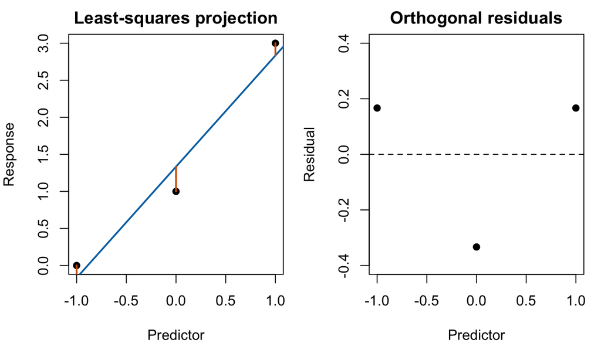

```r
par(mfrow=c(1,2), mar=c(4,4,2,1), cex=1)
plot(z_small, y_small, pch=19, xlab="Predictor", ylab="Response",
     main="Least-squares projection")
abline(beta_hat, col="#0072B2", lwd=2)
segments(z_small, y_small, z_small, x_small %*% beta_hat,
         col="#D55E00", lwd=2)
plot(z_small, residual, pch=19, ylim=c(-.4,.4),
     xlab="Predictor", ylab="Residual", main="Orthogonal residuals")
abline(h=0, lty=2)
```

```r
par(mfrow=c(1,1))
```

There is only one residual degree of freedom. Three rows do not mean three independent pieces of information about noise after two coefficients are fitted. **Extension:** duplicate the slope column. Verify that rank falls short of the number of coefficients, while the fitted response vector remains unique.

# Section 4.2 — Conjugate updates and joint simulation

**Concept.** A Gaussian coefficient prior scaled by the unknown residual variance gives a conjugate update. Drawing the variance first lets the coefficient draw inherit its uncertainty.

**Example.** Reuse the three-point dataset from Section 4.1 and put an independent-coefficient prior on the intercept and slope conditional on the variance. Estimate the probability that the intercept exceeds the slope.

Add prior and sample precisions in `reg_fit`, then compute the updated inverse-gamma scale from two nonnegative squared terms. `reg_draw` draws the variance first and uses the Cholesky factor for the conditional coefficients. These small examples use matrix solves; large or ill-conditioned problems should use suitable factorizations.

```r
reg_fit <- function(x, y, m0, v0, d0, s0) {
  stopifnot(nrow(x)==length(y), ncol(x)==length(m0), d0>0, s0>0)
  chol(v0)                         # verifies positive definiteness
  p0 <- solve(v0)
  vn <- solve(p0 + crossprod(x))
  mn <- drop(vn %*% (p0 %*% m0 + crossprod(x, y)))
  sn <- s0 + sum((y-x %*% mn)^2) +
    drop(crossprod(mn-m0, p0 %*% (mn-m0)))
  sn_check <- s0 + sum(y^2) + drop(crossprod(m0,p0 %*% m0)) -
    drop(crossprod(mn,solve(vn,mn)))
  stopifnot(abs(sn-sn_check) < 1e-8)
  list(x=x, mn=mn, vn=vn, dn=d0+length(y), sn=sn)
}
reg_draw <- function(fit, r) {
  sigma2 <- 1/rgamma(r, shape=fit$dn/2, rate=fit$sn/2)
  # R's chol is upper triangular; row-normal draws multiply on the right.
  beta <- matrix(rnorm(r*length(fit$mn)), nrow=r) %*% chol(fit$vn)
  beta <- sweep(sweep(beta,1,sqrt(sigma2),"*"),2,fit$mn,"+")
  list(beta=beta, sigma2=sigma2)
}
small_fit <- reg_fit(x_small,y_small,c(0,0),diag(2),4,2)
stopifnot(max(abs(small_fit$mn-c(1,1))) < 1e-12,
          max(abs(small_fit$vn-diag(c(1/4,1/3)))) < 1e-12,
          small_fit$dn==7, abs(small_fit$sn-5) < 1e-12)
small_fit[c("mn","vn","dn","sn")]
```

```
## $mn
## intercept         z
##         1         1
##
## $vn
##           intercept         z
## intercept      0.25 0.0000000
## z              0.00 0.3333333
##
## $dn
## [1] 7
##
## $sn
## [1] 5
```

```r
set.seed(4102)
small_draw <- reg_draw(small_fit,20000)
difference <- small_draw$beta[,1]-small_draw$beta[,2]
p_hat <- mean(difference>0)
c(estimate=p_hat, exact=.5, MCSE=sqrt(p_hat*(1-p_hat)/length(difference)))
```

```
##    estimate       exact        MCSE
## 0.500550000 0.500000000 0.003535532
```

```r
stopifnot(abs(p_hat-.5) < 5*sqrt(.25/length(difference)))
```

The posterior mean of the residual variance is one. The reference analysis of the same data is proper but has an infinite variance mean, because its inverse-gamma shape is only one half. This is a model choice, not simulation error.

**Example.** For the 50 stopping distances in `datasets::cars`, estimate how much mean stopping distance increases from 15 to 25 mph.

Center speed at 15 mph and scale it in units of 10 mph. Under this coding, the linear slope is the mean difference of interest. Use its Student posterior to get an interval and the probability that it exceeds 30 feet.

```r
cars_data <- datasets::cars
stopifnot(nrow(cars_data)==50, !anyNA(cars_data),
          identical(range(cars_data$speed),c(4,25)))
z_cars <- (cars_data$speed-15)/10
y_cars <- cars_data$dist
x_linear <- cbind(1,z_cars)
x_quadratic <- cbind(1,z_cars,z_cars^2)
fit_linear <- reg_fit(x_linear,y_cars,c(40,30),diag(c(4,4)),6,900)
fit_quadratic <- reg_fit(x_quadratic,y_cars,c(40,30,0),diag(c(4,4,1)),6,900)
fit_linear[c("mn","vn","dn","sn")]
```

```
## $mn
##            z_cars
## 41.40665 39.15800
##
## $vn
##                           z_cars
##         0.020014051 -0.002853037
## z_cars -0.002853037  0.071682543
##
## $dn
## [1] 56
##
## $sn
## [1] 12275.36
```

```r
slope_scale <- sqrt(fit_linear$sn/fit_linear$dn*fit_linear$vn[2,2])
c(mean=fit_linear$mn[2],
  lower=fit_linear$mn[2]+qt(.025,fit_linear$dn)*slope_scale,
  upper=fit_linear$mn[2]+qt(.975,fit_linear$dn)*slope_scale,
  probability_above_30=pt((fit_linear$mn[2]-30)/slope_scale,fit_linear$dn))
```

```
##                 mean.z_cars                lower.z_cars
##                  39.1579976                  31.2172205
##                upper.z_cars probability_above_30.z_cars
##                  47.0987747                   0.9877104
```

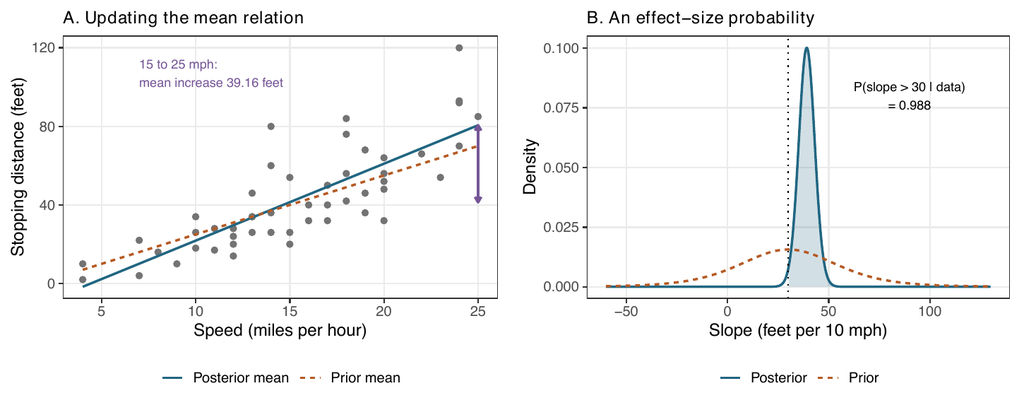

Lecture notes, Section 4.2. The arrow spans the posterior mean distances at 15 and 25 mph.

```r
stopifnot(max(abs(fit_linear$mn-c(41.407,39.158))) < .001,
          abs(fit_linear$sn-12275.36)<.01)
```

**Extension:** set the two columns of a design equal, keeping a proper prior. Compare posterior variation along their sum and difference. Then investigate why replacing the proper prior by the reference kernel makes the posterior improper.

# Section 4.3 — Prior scales and directional shrinkage

**Concept.** A spherical coefficient prior shrinks weak design directions more strongly. A g-prior uses the design geometry and retains the same fraction in each direction.

**Example.** Start with design information 100 and 1 in two directions. Then look at what the coefficient prior implies for mean stopping distance.

Compute data-retention factors in the two directions. Refit after recoding speed and transforming its prior to check that predicted means and their covariance are invariant to a consistent change of units.

```r
eigenvalues <- c(100,1)
h0 <- 1; g0 <- 4
cbind(design_information=eigenvalues,
      ridge=eigenvalues/(eigenvalues+h0^(-2)),
      g_prior=rep(g0/(g0+1),2))
```

```
##      design_information    ridge g_prior
## [1,]                100 0.990099     0.8
## [2,]                  1 0.500000     0.8
```

```r
# Transforming both design and prior preserves the fitted distribution.
x_recoded <- x_linear %*% diag(c(1,100))
h_inv <- diag(c(1,.01))
fit_recoded <- reg_fit(x_recoded,y_cars,
                      drop(h_inv %*% c(40,30)),
                      h_inv %*% diag(c(4,4)) %*% h_inv,6,900)
stopifnot(max(abs(x_recoded %*% fit_recoded$mn -
                 x_linear %*% fit_linear$mn)) < 1e-10,
          max(abs(x_recoded %*% fit_recoded$vn %*% t(x_recoded) -
                  x_linear %*% fit_linear$vn %*% t(x_linear))) < 1e-10)
```

For the stopping-distance data, compare the initial covariance multiplier of four with one quarter. Keep the prior center and variance prior fixed.

```r
fit_tighter <- reg_fit(x_linear, y_cars, c(40, 30), diag(c(.25, .25)),
                      d0 = 6, s0 = 900)
slope_interval <- function(fit) {
  scale <- sqrt(fit$sn / fit$dn * fit$vn[2, 2])
  fit$mn[2] + scale * qt(c(.025, .5, .975), fit$dn)
}
intervals <- rbind(original = slope_interval(fit_linear),
                   tighter = slope_interval(fit_tighter))
colnames(intervals) <- c("2.5%", "Median", "97.5%")
intervals
```

```
##              2.5%   Median    97.5%
## original 31.21722 39.15800 47.09877
## tighter  30.10793 37.22943 44.35092
```

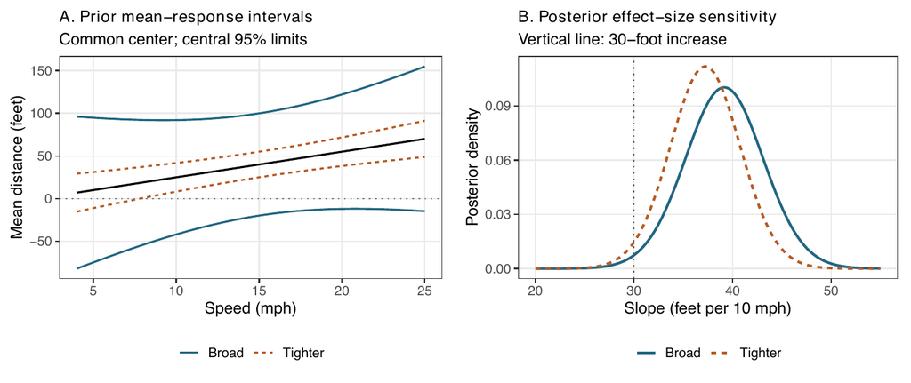

Lecture notes, Section 4.3. Prior mean curves and marginal slope posteriors under the two prior scales.

The prior permits negative mean distances at some speeds. Diffuseness is not a substitute for plausible predictions. **Extension:** multiply the linear-model slope prior variance by four while keeping the intercept prior fixed. Compare negative-mean probabilities and the posterior slope interval.

# Section 4.4 — Prediction, extrapolation, and a targeted check

**Concept.** A future response has uncertainty from the regression mean and residual noise. Extrapolation can also reveal sensitivity to the model’s functional form.

**Example.** Compare linear and quadratic stopping-distance predictions at 15 mph and at 35 mph, beyond the observed range.

Compute the Student intervals from the fitted model. The mean-response scale uses the new design row’s leverage. The future-response scale adds the unit contribution from residual noise.

```r
reg_predict <- function(fit,new_x) {
  h <- rowSums((new_x %*% fit$vn)*new_x)
  center <- drop(new_x %*% fit$mn)
  width_mean <- qt(.975,fit$dn)*sqrt(fit$sn/fit$dn*h)
  width_future <- qt(.975,fit$dn)*sqrt(fit$sn/fit$dn*(1+h))
  data.frame(center,mean_lo=center-width_mean,mean_hi=center+width_mean,
             future_lo=center-width_future,future_hi=center+width_future)
}
speeds <- c(15,35)
z_new <- (speeds-15)/10
linear_report <- reg_predict(fit_linear,cbind(1,z_new))
quadratic_report <- reg_predict(fit_quadratic,cbind(1,z_new,z_new^2))
cbind(speed=speeds,linear_report)
```

```
##   speed    center   mean_lo   mean_hi future_lo future_hi
## 1    15  41.40665  37.21076  45.60253  11.45233  71.36096
## 2    35 119.72264 103.60462 135.84066  85.96696 153.47832
```

```r
cbind(speed=speeds,quadratic_report)
```

```
##   speed    center   mean_lo   mean_hi future_lo future_hi
## 1    15  39.10854  33.91164  44.30544  9.532967  68.68411
## 2    35 150.70481 105.14746 196.26217 96.638379 204.77125
```

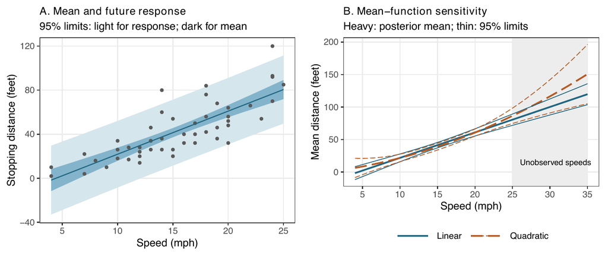

Lecture notes, Section 4.4. The panels compare interval targets and model forms.

```r
stopifnot(abs(linear_report$center[1]-41.407)<.001,
          abs(quadratic_report$center[2]-150.70)<.01)
```

The new-response interval contains residual noise as well as uncertainty about the mean. At 35 mph, both models extrapolate beyond every observed speed; their disagreement is additional to the uncertainty represented within either model.

## A predictive check for curvature

**Concept.** A predictive check uses a discrepancy that targets a specific aspect of model fit and asks how unusual the observed value is under posterior replications.

**Example.** To check curvature in the stopping-distance data, use the absolute coefficient of the quadratic term from an auxiliary least-squares fit. The same linear weights extract this coefficient from the observed data and every replication, so matrix multiplication is exactly equivalent to refitting all auxiliary regressions.

```r
curvature_weights <- qr.solve(x_quadratic,diag(nrow(x_quadratic)))[3,]
t_observed <- abs(sum(curvature_weights*y_cars))
exact_check <- function(fit) {
  ax <- drop(crossprod(fit$x,curvature_weights))
  center <- sum(ax*fit$mn)
  scale <- sqrt(fit$sn/fit$dn *
    (sum(curvature_weights^2)+drop(crossprod(ax,fit$vn %*% ax))))
  tail_area <- pt((-t_observed-center)/scale,fit$dn) +
    pt((center-t_observed)/scale,fit$dn)
  list(center=center,scale=scale,df=fit$dn,tail=tail_area)
}
replicate_check <- function(fit,r=20000) {
  draws <- reg_draw(fit,r)
  means <- draws$beta %*% t(fit$x)
  replicated <- means + sweep(matrix(rnorm(length(means)),nrow=r),
                              1,sqrt(draws$sigma2),"*")
  discrepancies <- abs(drop(replicated %*% curvature_weights))
  estimate <- mean(discrepancies>=t_observed)
  exact <- exact_check(fit)$tail
  se <- sqrt(exact*(1-exact)/r)
  stopifnot(abs(estimate-exact)<5*se)
  list(discrepancies=discrepancies,estimate=estimate,exact=exact,MCSE=se)
}
set.seed(50012026)
linear_check <- replicate_check(fit_linear)
quadratic_check <- replicate_check(fit_quadratic)
c(observed=t_observed,linear_check[c("estimate","exact","MCSE")])
```

```
## $observed
## [1] 9.99593
##
## $estimate
## [1] 0.1257
##
## $exact
## [1] 0.1260115
##
## $MCSE
## [1] 0.002346621
```

```r
c(quadratic_check[c("estimate","exact","MCSE")])
```

```
## $estimate
## [1] 0.4457
##
## $exact
## [1] 0.4446918
##
## $MCSE
## [1] 0.003513837
```

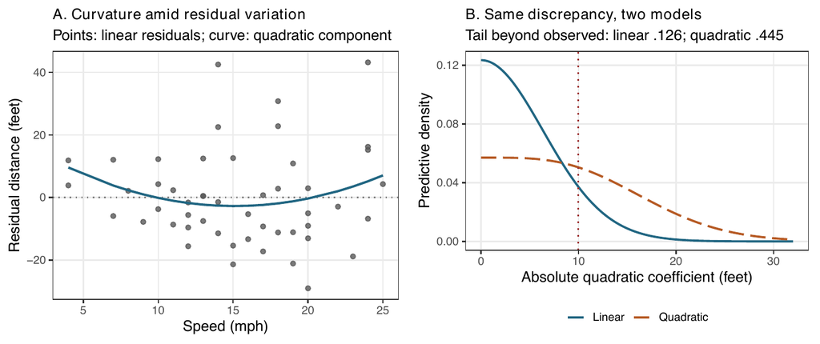

Lecture notes, Section 4.4. The right panel shows the exact discrepancy densities used to check the simulation.

```r
stopifnot(abs(t_observed-9.996)<.001,
          abs(linear_check$exact-.126)<.001,
          abs(quadratic_check$exact-.445)<.001)
```

A model can reproduce this discrepancy and still miss variance changes or outliers. The same responses motivated the quadratic revision, so passing its curvature check is not independent validation. **Extension:** halve and double the prior standard deviation of the quadratic coefficient. Repeat prediction at 15 and 35 mph and the check; report which conclusion is most sensitive.

R 4.6.0 · BayesComp 0.1.0